```python
from bs4 import BeautifulSoup #beautifulsoup4
import pandas as pd
import requests as req
from random import randint
from time import sleep
import matplotlib.pyplot as plt
import numpy as np
```

# The National UFO Reporting Center: UFO Sightings?

## Introduction

The [National UFO Reporting Center (NUFORC)](http://www.nuforc.org/) was founded in 1974 in the United States by Robert J. Gribble. Peter Davenport, the current director, has served as such since 1994. While most reports have little evidence proving their legitimacy, relying on eyewitness testimony, NUFORC's primary function is to document and corroborate individuals' reports of unusual, possibly UFO-related events. NUFORC stands out for [their entirely public database](http://www.nuforc.org/webreports.html) of UFO reports, which has catalogued more than 130,000 reported possible UFO sightings.

The possibility of life among the stars is one that has fascinated humans for decades, and has become a staple in science fiction entertainment. Despite having seeped into and integrated with the public consciousness, aliens and UFO sightings are treated with a healthy dose of skepticism by the general public, and for good reason. Despite the apparent high probability that we are not alone in this universe (that life spontaneously bloomed on more than just the little rock we call home), no convincing evidence of aliens has been found. This is the Fermi paradox: But where are all the aliens?

While it is unlikely that we will succeed in answering these questions where many others have failed, analyzing the patterns of apparent UFO sightings will perhaps allow us to find alternative explanations, and may allow us to better understand how the general public interprets unexplainable phenomena through the lense of their culture.

## Data Collection

First, we need to actually obtain the data we will be using. We will do this by scraping the data from NUFORC's existing tables. Due to the format of the site, we must scrape multiple webpages for a complete set of data. The data is indexed by 4 different features: event date, state, shape of ufo, and date posted, with each value of the index leading to a webpage containing the associated data.

We will start at the webpage containing links to all reported UFO sightings indexed by the shape, as it requires accessing the least amount of additional webpages, and use the html soup we scrape from this page to get the urls we must access for the data.

```python
web = req.get('http://www.nuforc.org/webreports/ndxshape.html') # requests data from webpage
soup = BeautifulSoup(web.text, 'html.parser') # parses the data from the webpage as html and makes it readable
```

Using the scraped html information, we will loop through the links found on the webpage, scraping the relevant information on each linked page and adding it to a table. Due to the fact that NUFORC was established in 1974, and thus all reports prior to this year are far more likely to be unreliable, we will only be scraping data from the year 1974 to the current year.

```python
first = True
for a in soup.find_all('a', href=True): # loops through each link found on the starting webpage
    rand = randint(1,5) # random value generated
    url = a['href'] # sets link to a variable for easier use
    if first: # first = True indicates a table must be created, not added to
        if(url.find('http') != -1): # if url refers to a specific webpage (path) rather than containing a full url
            web = req.get(('http://www.nuforc.org/webreports/' + str(url))) # requests data using url path
            soup = BeautifulSoup(web.text, 'html.parser') # parses the data from the webpage as html and makes it readable
            dfs = pd.read_html(web.text, flavor='bs4') # reads html and puts the data into dataframes
            ufos = dfs[0] # selecting the dataframe that contains the data from the webpage's table and creating a new dataframe from it
            first = False # first is set to False now that a dataframe for the data has been created: ufos
    else:
        web = req.get(('http://www.nuforc.org/webreports/' + str(url))) # requests data using url path
        soup = BeautifulSoup(web.text, 'html.parser') # parses the data from the webpage as html and makes it readable
        dfs = pd.read_html(web.text, flavor='bs4') # reads html and puts the data into dataframes
        ufos = pd.concat([ufos,dfs[0]]) # sets ufos dataframe to the concatenation of the previous ufos dataframe and the dataframe containing the new data scraped from the webpage table

    sleep(rand) # sleep a random number of seconds; this is done so that connection to the NUFORC website isn't refused after multiple repeated connection attempts
    print('Waited ', rand, 'seconds.')
```

```
Waited  5 seconds.
Waited  4 seconds.
Waited  5 seconds.
Waited  1 seconds.
Waited  4 seconds.
Waited  4 seconds.
Waited  4 seconds.
Waited  2 seconds.
Waited  5 seconds.
Waited  5 seconds.
Waited  3 seconds.
Waited  2 seconds.
Waited  2 seconds.
Waited  2 seconds.
Waited  1 seconds.
Waited  2 seconds.
Waited  3 seconds.
Waited  1 seconds.
Waited  1 seconds.
Waited  4 seconds.
Waited  1 seconds.
Waited  4 seconds.
Waited  5 seconds.
Waited  3 seconds.
Waited  3 seconds.
Waited  3 seconds.
Waited  5 seconds.
Waited  5 seconds.
Waited  4 seconds.
Waited  1 seconds.
Waited  5 seconds.
Waited  2 seconds.
```

```python
ufos_orig = ufos # saving the original scraped data just in case
```

## Data Clean-Up

Now that we have our data, we need to clean it up so that we can process it for future analysis. Due to the fact that NUFORC accepts reports through an online form as well as through their hotline, some of the data in the reports is inconsistently formatted

```python
ufos
```

|  | 0 | City | Date / Time | Duration | Posted | Shape | State | Summary |
| --- | --- | --- | --- | --- | --- | --- | --- | --- |
| 0 | The page cannot be found The page you are look... | NaN | NaN | NaN | NaN | NaN | NaN | NaN |
| 0 | NaN | Osceola | 6/14/21 01:00 | 20 min | 7/31/21 | NaN | IA | My report is that I sited a UFO and they may b... |
| 1 | NaN | Ball Ground | 6/6/21 02:25 | NaN | 7/31/21 | NaN | GA | MADAR Node 129 |
| 2 | NaN | Mt. Vernon | 6/6/21 01:25 | NaN | 7/31/21 | NaN | IN | MADAR Node 119 |
| 3 | NaN | Estes Park | 6/6/21 00:25 | NaN | 7/31/21 | NaN | CO | MADAR Node 156 |
| ... | ... | ... | ... | ... | ... | ... | ... | ... |
| 9217 | NaN | South Milwaukee | unknown | 1 to 2 minutes | 9/2/05 | Unknown | WI | Saw two faceless aliens in the woods.Was witne... |
| 9218 | NaN | Little Rock (5 miles west of) | NaN | 25 minutes | 1/31/20 | Unknown | AR | A bright orange light hovering to the west of ... |
| 9219 | NaN | Rule | NaN | 15 minutes | 8/19/12 | Unknown | TX | Unusual sounds and starlight distortion defini... |
| 9220 | NaN | Somerset | NaN | 2400 hours | 12/22/19 | Unknown | KY | One object observed at closer ground distance,... |
| 9221 | NaN | Oscoda | 09?/?/1975 | 2-3 min | 6/6/00 | Unknown | MI | Funny flashing lights that hovered then just d... |

134842 rows × 8 columns

First, we need to delete the '0' column from the table; the only information it contains is an error message from when a webpage could not be reached. Then, we will drop any rows with missing data recorded as a null value (NaN) to cull the data down to only complete reports.

```python
del ufos[0]
ufos = ufos.dropna() # drop any rows with missing data
ufos.columns = ['city', 'datetime', 'duration', 'post_date', 'shape', 'state', 'summary'] # rename columns to something easier to use
ufos
```

|  | city | datetime | duration | post_date | shape | state | summary |
| --- | --- | --- | --- | --- | --- | --- | --- |
| 0 | Aurora | 6/24/96 00:30 | 1 hour | 11/2/99 | changed | CO | Obj. hovered 100 ft above car. Red, blue light... |
| 0 | Delmont | 6/19/21 17:10 | 20 Seconds | 7/31/21 | Changing | PA | Delmont, Pa Flying object interchanging shapes... |
| 1 | Old Hickory | 6/17/21 15:30 | 30 sec | 7/31/21 | Changing | TN | Just got done swimming and about head to the s... |
| 2 | New York Ciity (Brooklyn) | 6/16/21 19:30 | 1 hour | 7/31/21 | Changing | NY | Black changing shape with halo hovering over W... |
| 3 | Bonsall | 6/13/21 16:00 | 3 minutes | 7/31/21 | Changing | CA | UFO spotted by flight instructor and student p... |
| ... | ... | ... | ... | ... | ... | ... | ... |
| 9213 | Ocean Springs | 1984-85 01:00 | 30 min | 12/22/19 | Unknown | MS | Close encounter of the third kind mid 1980's |
| 9214 | Atlanta | 5/20/20014 00:00 | 2 seconds | 4/11/14 | Unknown | GA | ((HOAX??)) green flash above tree line while o... |
| 9216 | Trevorton | ??/??/?? | Long Ago | 2/22/02 | Unknown | PA | Fast UFO flyies across mountain areas. Telsa P... |
| 9217 | South Milwaukee | unknown | 1 to 2 minutes | 9/2/05 | Unknown | WI | Saw two faceless aliens in the woods.Was witne... |
| 9221 | Oscoda | 09?/?/1975 | 2-3 min | 6/6/00 | Unknown | MI | Funny flashing lights that hovered then just d... |

117330 rows × 7 columns

Now that we have our data, we need to change the datatype of the columns involving time from strings to datetime/timedelta so that they can be used in calculations and sorting the data by time. The 'datetime' and 'post_date' columns will be converted to datetime (which represents a specific date and time), and the duration will be converted to timedelta (which represents some period/amount of time).

```python
ufos['datetime'] = pd.to_datetime(ufos['datetime'], infer_datetime_format=True, errors='coerce')
# translate the strings in the 'datetime' column into actual datetime; those without proper formatting are set to null
ufos['post_date'] = pd.to_datetime(ufos['post_date'], infer_datetime_format=True, errors='coerce')
# translate the strings in the 'post_date' column into actual datetime; those without proper formatting are set to null
ufos['duration'] = ufos['duration'].apply(lambda x: pd.to_timedelta(x, errors='coerce'))
# translate the strings in the 'duration' column into timedelta; those without proper formatting are set to null
```

Now that we have converted what information we can, we must further cull the data to remove any entries in the table that were not properly formatted and were replaced by null values. As we are most concerned with the date and time the ufo sighting occurred, we will only be doing this to the 'datetime' column; any processing that requires use of the 'post_date' or 'duration' columns can be done after further culling. By being more lenient in this, we don't lose as much data. An entry with a valid datetime, but an invalid duration may not be useful when attempting to analyze the data based on the duration feature, but it can still act as a valid datapoint when analyzing the data based on its datetime.

```python
ufos = ufos.drop(ufos[ufos['datetime'].isnull()].index) # any rows that contain a null datetime value are dropped
ufos = ufos.sort_values(by='datetime').reset_index() # resetting the index to account for dropped rows
del ufos['index']
```

```python
ufos
```

|  | city | datetime | duration | post_date | shape | state | summary |
| --- | --- | --- | --- | --- | --- | --- | --- |
| 0 | Roseville | 1962-01-01 20:00:00 | 0 days 00:02:00 | 1999-10-19 | Triangle | MI | This is the first time I ever reported this an... |
| 1 | Raymond | 1970-01-01 22:00:00 | 0 days 00:30:00 | 2001-10-12 | Disk | MS | BEINGS FROM SPACE ARE LIVING HERE ON EARTH. |
| 2 | Niagara Falls (Canada) | 1971-01-01 01:00:00 | 0 days 00:05:00 | 2000-12-02 | Oval | ON | In van driving home. Van stalled beside Winery... |
| 3 | La Ronge (Canada) | 1971-01-10 20:00:00 | 0 days 00:05:00 | 2001-04-01 | Unknown | SA | sighting at anglo rouyn mine in the early 1970... |
| 4 | Sioux City | 1971-01-15 22:00:00 | 0 days 00:10:00 | 2019-12-01 | Sphere | IA | My friend and I were on a country highway betw... |
| ... | ... | ... | ... | ... | ... | ... | ... |
| 116648 | Newton Centre | 2070-12-15 21:00:00 | -1 days +23:59:25 | 2010-08-24 | Other | MA | Vertical trapazoid having a glowing pale yello... |
| 116649 | Meriden | 2070-12-20 17:00:00 | 0 days 00:10:00 | 2012-07-04 | Unknown | CT | My parents & I just sat down for dinner when m... |
| 116650 | Lake Wales | 2070-12-21 19:00:00 | 0 days 00:05:00 | 2003-05-27 | Oval | FL | Pulled over by a ufo using police lights |
| 116651 | Berlin | 2070-12-24 18:00:00 | 0 days 00:05:00 | 2013-05-15 | Cylinder | NJ | Cylinder shape, not fast moving like you see i... |
| 116652 | Fairhaven | 2070-12-24 23:20:00 | 0 days 00:02:00 | 2017-04-07 | Disk | MA | As I looked up, I was in shock to see the unde... |

116653 rows × 7 columns

```python
ufos['month'] = ufos['datetime'].dt.month
ufos['year'] = ufos['datetime'].dt.year
```

To make processing and grouping easier in the future, we add two additional columns to the table, 'month' and 'year', taken from the 'datetime' column. We can then use the 'year' column values to cut the data down to only include data from the years 1974 to 2020. The reason we are limiting the data to these years is because 1) NUFORC was not established until 1974, meaning any reports of occurrences prior to that year are less likely to be reliably accurate, and 2) 2020 is the most recent year we have complete data for; 2021 is not over, and including it could skew the data, especially when looking at UFO sighting count totals.

```python
ufos = ufos[ufos['year']<2021] # removes any ufo sightings that were recorded as taking place in the future
ufos = ufos[ufos['year']>1973] # removes any ufo sightings that were reported as taking place prior to the establishment of NUFORC
ufos = ufos.reset_index()
del ufos['index']
ufos
```

|  | city | datetime | duration | post_date | shape | state | summary | month | year |
| --- | --- | --- | --- | --- | --- | --- | --- | --- | --- |
| 0 | Kent | 1974-01-01 01:00:00 | NaT | 1999-01-28 | Cigar | WA | Cigar shaped with distint window shapes the wi... | 1 | 1974 |
| 1 | Brooklyn | 1974-01-01 03:00:00 | 0 days 00:15:00 | 2015-04-03 | Circle | TX | A large circular spaceship appeared overhead w... | 1 | 1974 |
| 2 | Lancaster | 1974-01-07 21:40:00 | 0 days 00:15:00 | 2020-01-31 | Other | OH | Dozens of uniform, same speed, random pattern ... | 1 | 1974 |
| 3 | Carbondale | 1974-01-09 21:00:00 | NaT | 1999-10-19 | Circle | PA | A circular object flew across the sky and fell... | 1 | 1974 |
| 4 | Terre Haute | 1974-01-15 05:00:00 | 0 days 00:20:00 | 2003-11-26 | Disk | IN | UFO tampreing with comunication towers in Terr... | 1 | 1974 |
| ... | ... | ... | ... | ... | ... | ... | ... | ... | ... |
| 112365 | Nazareth | 2020-12-31 22:30:00 | 0 days 00:02:00 | 2021-01-19 | Fireball | PA | Pulsating orange orb in eastern sky | 12 | 2020 |
| 112366 | Ashland | 2020-12-31 22:30:00 | -1 days +07:05:00 | 2021-01-19 | Sphere | NH | Large, brightly glowing orange spheres, which ... | 12 | 2020 |
| 112367 | Caldwell | 2020-12-31 22:38:00 | 0 days 00:02:00 | 2021-01-19 | Circle | ID | Out back on my patio, my wife and i saw a very... | 12 | 2020 |
| 112368 | Palm Springs | 2020-12-31 23:10:00 | 0 days 00:03:00 | 2021-01-19 | Formation | CA | 4 orange lights , one behind the other. Then a... | 12 | 2020 |
| 112369 | Damascus | 2020-12-31 23:30:00 | NaT | 2021-01-19 | Fireball | MD | Red sphere transitions into an eye... | 12 | 2020 |

112370 rows × 9 columns

Lastly, we need to retrieve some additional information to use later. As the states are all recorded as their state codes, we need a way to determine which of these codes are valid states, and which states are represented by which code. We can do this easily by retrieving a csv file that contains all of the states and their associated codes from the World Population Review, [here](https://worldpopulationreview.com/states/state-abbreviations).

```python
states = pd.read_csv('us_states.csv') # using the data obtained from this csv file in order to know which state abbreviations are legitimate
# file from https://worldpopulationreview.com/states/state-abbreviations
```

## Data Visualization and Analysis

Now that we have cleaned up the data to make it easier to work with, we can begin processing the data and looking for correlations between features. First, let's take a look at the frequency of ufo sightings over time, from the year NUFORC was established in 1974 to 2020 (as 2021 isn't over yet, its data is technically incomplete and we will be leaving it out in this particular instance).

```python
# number of ufo sightings over time (sightings per year, 1974-2020)

ufos_per_year = ufos.groupby(ufos.datetime.dt.year)['datetime'].count()
ufos_per_year = ufos_per_year.head(2021-1974)
ufos_per_year
```

```
datetime
1974     301
1975     350
1976     317
1977     302
1978     372
1979     277
1980     275
1981     191
1982     212
1983     176
1984     193
1985     241
1986     202
1987     251
```

[output cut: 34 more lines]

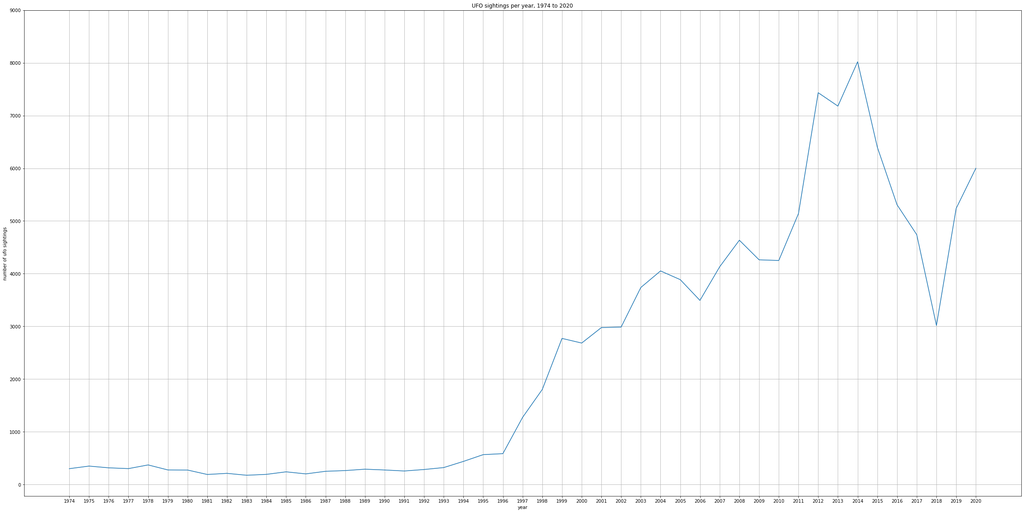

```python
ufos_per_year.plot(figsize=(40,20), grid=True, title='UFO sightings per year, 1974 to 2020', xlabel='year', ylabel='number of ufo sightings', xticks=range(1974,2021,1), yticks=range(0,9001, 1000))
```

The most obvious change is the sudden growth in the number of ufo sightings beginning in 1996; while it is certainly possible there are other factors influencing this growth, this can most likely be attributed to the advent of [widespread home internet access](https://www.scienceandmediamuseum.org.uk/objects-and-stories/short-history-internet) during this time, as well as the creation and publication of NUFORC's website, which allowed the submission of reports online, and provided an alternative method to calling NUFORC's hotline. Through the internet, word of NUFORC's goal was able to spread to interested parties far more easily than before, where it likely would have largely been through word of mouth or through existing lines of communication in the ufo community.

One of the most dramatic increases in the number of reported ufo sightings occurred between 2011 and 2012, with a more than 2000 report increase, though this is not the only instance of a dramatic change in the number of reports received. A possible reason for this increase is an increase in public perception and attention. 2012 was the year the Mayan calendar ended, and conspiracies of an apocalypse made national news. [The Maya calendar was based heavily in astronomy](https://www.historymuseum.ca/cmc/exhibitions/civil/maya/mmc07eng.html), and consists of several cycles. The Maya developed some of the most accurate astronomy prior to the invention of telescopes in the world. This association with space and cycles lead some to speculate that some sort of galactic alignment or other galactic phenomenon would cause the 2012 doomsday, and some even claimed the possibility of an alien invasion. As the idea spread through the public via the internet, it seems likely that there would be an increase in traffic on related websites, such as NUFORC. It is possible that the increase could have been purely caused by an increase in attention and awareness, but it is also a possibile that the number of reported ufo sightings was artificially inflated by people who, with galactic cataclysms and alien invasions on the mind, were [more likely to jump to the conclusion](https://www.verywellmind.com/priming-and-the-psychology-of-memory-4173092) that what they had seen was a ufo, when otherwise they may have simply dismissed the strange occurrence.

Now, let's look to see if there are any trends over a year in the number of ufo sightings by averaging the number of sightings for each month.

```python
# avg number of ufo sightings over a year
avg_ufos_per_month = ufos.groupby([ufos['month'], ufos['year']])['datetime'].count()
avg_ufos_per_month = avg_ufos_per_month.groupby(['month']).mean()
avg_ufos_per_month
```

```
month
1     161.361702
2     135.531915
3     159.063830
4     165.787234
5     163.936170
6     219.489362
7     287.170213
8     251.000000
9     233.936170
10    229.957447
11    208.936170
12    174.680851
Name: datetime, dtype: float64
```

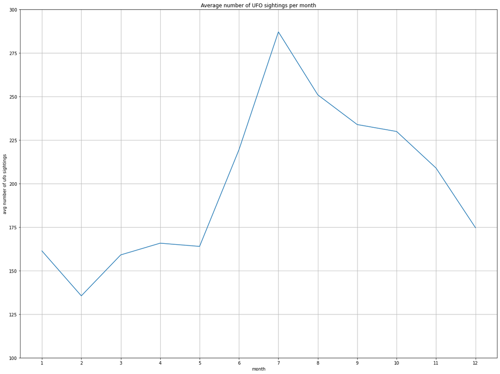

```python
avg_ufos_per_month.plot(figsize=(20,15), grid=True, title='Average number of UFO sightings per month', xlabel='month', ylabel='avg number of ufo sightings', xticks=range(1,13,1), yticks=range(100,301, 25))
```

There appears to be a trend, here; the average number of UFO sightings appears to increase between the months of February(2) and July(7), with the most dramatic rate of change occuring between May(5) and July(7), at which an apparent peak is reached. After this peak is reached in July(7), the number of UFO sightings steadily decreases between the months of July(7) and December(12), and then January(1). To look at this another way, lets try looking at the months as grouped by seasons.

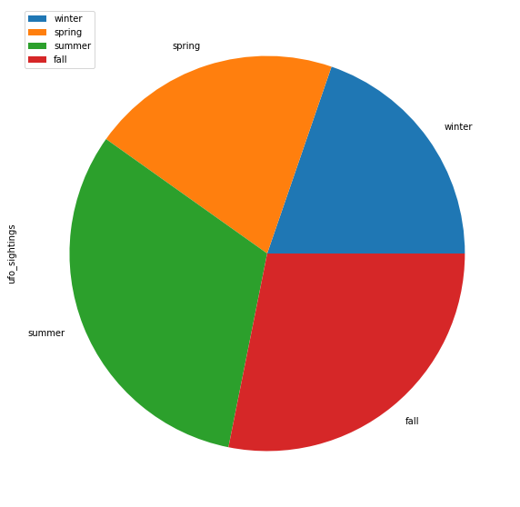

```python
# total number of ufos per season

# winter = Dec, Jan, Feb
# spring = March, April, May
# summer = June, July, August
# fall = Sept, Oct, Nov

winter = ufos[ufos['month'].isin([12,1,2])].count().values[0]
spring = ufos[ufos['month'].isin([3,4,5])].count().values[0]
summer = ufos[ufos['month'].isin([6,7,8])].count().values[0]
fall = ufos[ufos['month'].isin([9,10,11])].count().values[0]
seasons = pd.DataFrame({'ufo_sightings':[winter,spring,summer,fall]},index=['winter','spring','summer','fall'])
seasons.plot(kind='pie',y='ufo_sightings',figsize=(10,10))
```

As we can see from this pie chart, the most ufo sightings occurred in summer, with fall a fairly close second. This supports what we saw in the previous graph, but also indicates that the difference in the number of sightings may not be as large as the previous graph makes it appear. While summer is still in the lead, fall is much closer in number of sightings than at first glance.

Now that we have a basis for the frequency of ufo sightings as a function of time, let's look at how other features impact the number of ufo sightings, starting with location.

```python
ufos_per_state = ufos[ufos['state'].isin(states['Code'])]
ufos_out_of_states = ufos[~ufos['state'].isin(states['Code'])]
```

While NUFORC is a primarily US-based organization, there have been some UFO reports from outside of the USA; reports from outside the USA are being left out in this case, as the grouping is based on state.

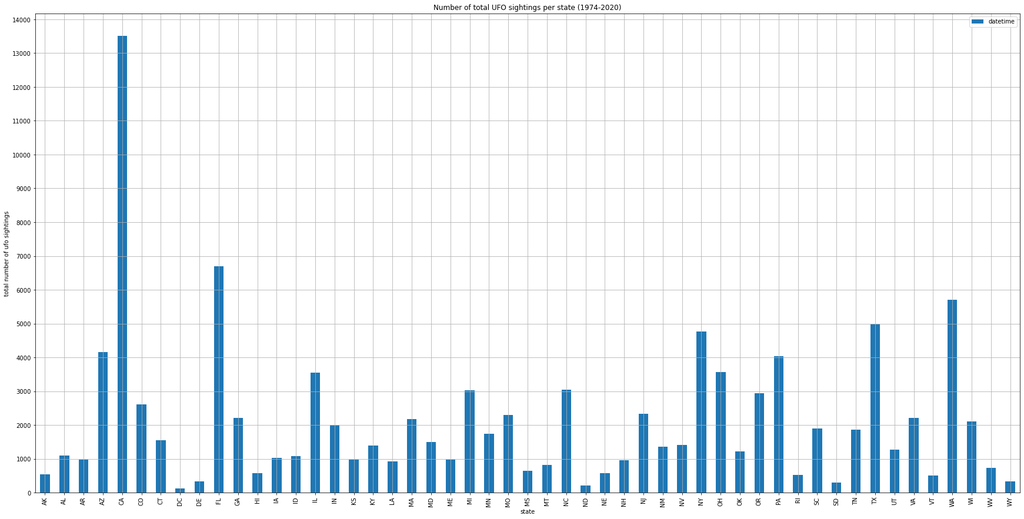

```python
# total number of ufo sightings per state
ufos_state_count = pd.DataFrame(ufos_per_state.groupby([ufos_per_state['state']])['datetime'].count())
ufos_state_count.plot(kind='bar', figsize=(30,15), grid=True, title='Number of total UFO sightings per state (1974-2020)', xlabel='state', ylabel='total number of ufo sightings', yticks=range(0,14001,1000))
```

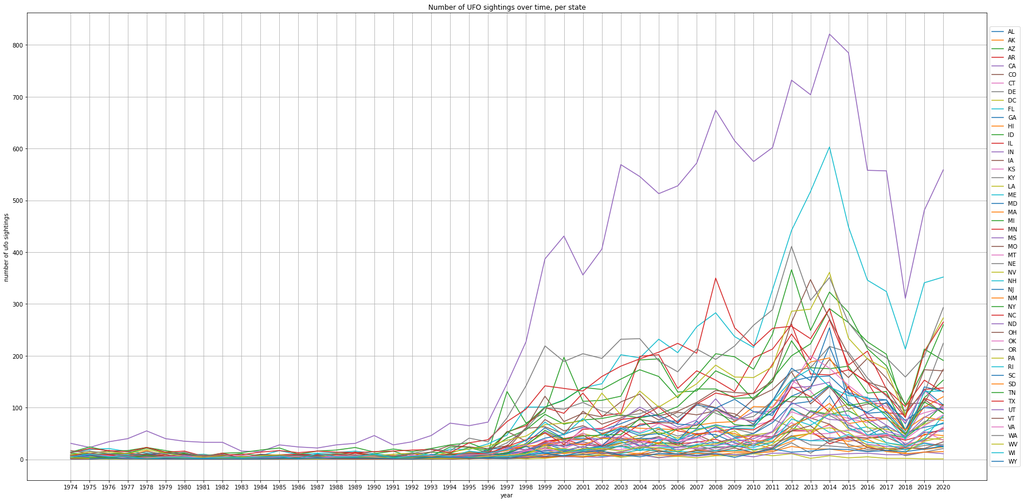

```python
# total number of ufo sightings per state from 1974-2020

ufos_per_state_count = ufos_per_state.groupby([ufos_per_state['state'], ufos_per_state['year']])['datetime'].count()

for state in states['Code']:
    ufos_per_state_count[state].plot(figsize=(30,15), grid=True, title='Number of UFO sightings over time, per state', xlabel='year', ylabel='number of ufo sightings', xticks=range(1974,2021,1), yticks=range(0,801, 100), label=state).legend(loc='center left',bbox_to_anchor=(1.0, 0.5))

ufos_state_count.reset_index(inplace=True) # for later
```

This is a lot of information, but the important part is that we can see that there is a clear outlier. Unfortunately, despite our helpful legend, pandas reuses line colors, and we don't have a clear way of telling which state represented in purple our outlier is. So, we have to turn to another python graphing tool: matplotlib!

Through matplotlib, we can use a colormap that will allow us to better distinguish between the many lines representing each state. Matplotlib provides an alternative method of graphing data in python, and in some respects allows the user to exert more control over the graph than if you were just to use pandas' dataframe.plot() function, as we have been previously.

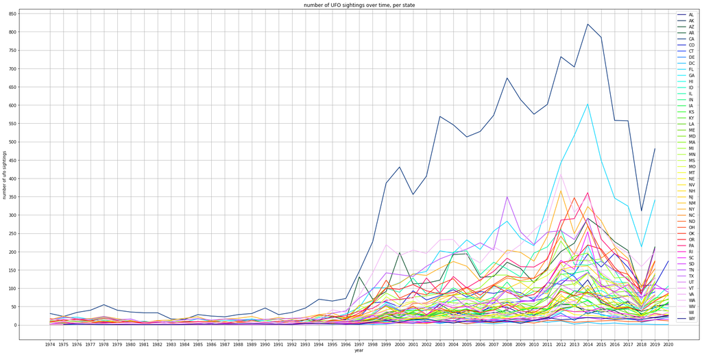

```python
num_colors = 50
color_map = plt.get_cmap('gist_ncar')
fig = plt.figure()
ax = fig.add_subplot(111)

ax.set_prop_cycle(color=[color_map(1.*i/num_colors) for i in range(num_colors)])

for state in states['Code']:
    plt.plot(ufos_per_state_count[state].head(2020-1974), label=state)
fig.set_size_inches(30,15,forward=True)
plt.legend()
plt.xlabel('year')
plt.ylabel('number of ufo sightings')
plt.title('number of UFO sightings over time, per state')
plt.xticks(range(1974,2021,1))
plt.yticks(range(0,851,50))
plt.grid(True)
```

The biggest outlier in this graph is California (CA). The number of ufo sightings reported every year in California is consistently higher than the number reported in any other states, and this gap has only grown as the number of reported ufo sightings has increased. Florida (FL), the state that has the second highest number of ufo reports since 2010, at which point it begins to become a potential outlier; Florida has consistently higher numbers than other states (excluding California) beginning in 2011, but its numbers are still dwarfed by California.

In order to find possible causes of this dramatic difference, lets take a look at population. If we assume the difference in number of ufo sightings is (at least in part) a factor of total population, it is unsurprising that California has the largest population in the USA as of 2021. Florida, the state with the second most amount of ufo reports, comes in third in terms of population.

Population clearly isn't everything, however, as the state with the second largest population in the USA, Texas, does not have so obvious a lead in terms of number of ufo sightings.

Let's take a closer look at how population impacts the number of ufo reports by plotting them.

First, we should retrieve the population data we need. We can retrieve a csv file that includes all of the relevant information from [here](https://worldpopulationreview.com/states).

```python
state_pop_data = pd.read_csv('us_states_population_data.csv')
# file from https://worldpopulationreview.com/states

state_pop_data.columns = ['pop_rank','state_name','pop','growth','pop_2018','pop_2010','growth_since_2010','percent','pop_density_per_square_mile']
states.columns=['state_name','state_abbrev','state_code']
ufos_state_count.columns=['state_code','num_ufos']

state_pop_data.drop([30], inplace=True) # dropping Puerto Rico
state_pop_data.reset_index(inplace=True)
state_pop_data.drop('index', axis=1, inplace=True)
state_pop_data
```

|  | pop_rank | state_name | pop | growth | pop_2018 | pop_2010 | growth_since_2010 | percent | pop_density_per_square_mile |
| --- | --- | --- | --- | --- | --- | --- | --- | --- | --- |
| 0 | 1 | California | 39613493 | 0.0038 | 39461588 | 37319502 | 0.0615 | 0.1184 | 254.2929 |
| 1 | 2 | Texas | 29730311 | 0.0385 | 28628666 | 25241971 | 0.1778 | 0.0889 | 113.8081 |
| 2 | 3 | Florida | 21944577 | 0.0330 | 21244317 | 18845537 | 0.1644 | 0.0656 | 409.2229 |
| 3 | 4 | New York | 19299981 | -0.0118 | 19530351 | 19399878 | -0.0051 | 0.0577 | 409.5400 |
| 4 | 5 | Pennsylvania | 12804123 | 0.0003 | 12800922 | 12711160 | 0.0073 | 0.0383 | 286.1704 |
| 5 | 6 | Illinois | 12569321 | -0.0121 | 12723071 | 12840503 | -0.0211 | 0.0376 | 226.3967 |
| 6 | 7 | Ohio | 11714618 | 0.0033 | 11676341 | 11539336 | 0.0152 | 0.0350 | 286.6944 |
| 7 | 8 | Georgia | 10830007 | 0.0303 | 10511131 | 9711881 | 0.1151 | 0.0324 | 188.3054 |
| 8 | 9 | North Carolina | 10701022 | 0.0308 | 10381615 | 9574323 | 0.1177 | 0.0320 | 220.1041 |
| 9 | 10 | Michigan | 9992427 | 0.0008 | 9984072 | 9877510 | 0.0116 | 0.0299 | 176.7351 |
| 10 | 11 | New Jersey | 8874520 | -0.0013 | 8886025 | 8799446 | 0.0085 | 0.0265 | 1206.7609 |
| 11 | 12 | Virginia | 8603985 | 0.0121 | 8501286 | 8023699 | 0.0723 | 0.0257 | 217.8776 |
| 12 | 13 | Washington | 7796941 | 0.0363 | 7523869 | 6742830 | 0.1563 | 0.0233 | 117.3249 |
| 13 | 14 | Arizona | 7520103 | 0.0506 | 7158024 | 6407172 | 0.1737 | 0.0225 | 66.2016 |
| 14 | 15 | Tennessee | 6944260 | 0.0255 | 6771631 | 6355311 | 0.0927 | 0.0208 | 168.4069 |
| 15 | 16 | Massachusetts | 6912239 | 0.0043 | 6882635 | 6566307 | 0.0527 | 0.0207 | 886.1845 |
| 16 | 17 | Indiana | 6805663 | 0.0165 | 6695497 | 6490432 | 0.0486 | 0.0203 | 189.9644 |
| 17 | 18 | Missouri | 6169038 | 0.0077 | 6121623 | 5995974 | 0.0289 | 0.0184 | 89.7419 |
| 18 | 19 | Maryland | 6065436 | 0.0049 | 6035802 | 5788645 | 0.0478 | 0.0181 | 624.8518 |
| 19 | 20 | Colorado | 5893634 | 0.0356 | 5691287 | 5047349 | 0.1677 | 0.0176 | 56.8653 |
| 20 | 21 | Wisconsin | 5852490 | 0.0078 | 5807406 | 5690475 | 0.0285 | 0.0175 | 108.0633 |
| 21 | 22 | Minnesota | 5706398 | 0.0179 | 5606249 | 5310828 | 0.0745 | 0.0171 | 71.6641 |
| 22 | 23 | South Carolina | 5277830 | 0.0381 | 5084156 | 4635649 | 0.1385 | 0.0158 | 175.5707 |
| 23 | 24 | Alabama | 4934193 | 0.0095 | 4887681 | 4785437 | 0.0311 | 0.0147 | 97.4271 |
| 24 | 25 | Louisiana | 4627002 | -0.0070 | 4659690 | 4544532 | 0.0181 | 0.0138 | 107.0966 |
| 25 | 26 | Kentucky | 4480713 | 0.0044 | 4461153 | 4348181 | 0.0305 | 0.0134 | 113.4760 |
| 26 | 27 | Oregon | 4289439 | 0.0257 | 4181886 | 3837491 | 0.1178 | 0.0128 | 44.6872 |
| 27 | 28 | Oklahoma | 3990443 | 0.0127 | 3940235 | 3759944 | 0.0613 | 0.0119 | 58.1740 |
| 28 | 29 | Connecticut | 3552821 | -0.0052 | 3571520 | 3579114 | -0.0073 | 0.0106 | 733.7507 |
| 29 | 30 | Utah | 3310774 | 0.0499 | 3153550 | 2775332 | 0.1929 | 0.0099 | 40.2918 |
| 30 | 32 | Nevada | 3185786 | 0.0523 | 3027341 | 2702405 | 0.1789 | 0.0095 | 29.0195 |
| 31 | 33 | Iowa | 3167974 | 0.0061 | 3148618 | 3050745 | 0.0384 | 0.0095 | 56.7158 |
| 32 | 34 | Arkansas | 3033946 | 0.0080 | 3009733 | 2921964 | 0.0383 | 0.0091 | 58.3059 |
| 33 | 35 | Mississippi | 2966407 | -0.0049 | 2981020 | 2970548 | -0.0014 | 0.0089 | 63.2186 |
| 34 | 36 | Kansas | 2917224 | 0.0020 | 2911359 | 2858190 | 0.0207 | 0.0087 | 35.6808 |
| 35 | 37 | New Mexico | 2105005 | 0.0059 | 2092741 | 2064552 | 0.0196 | 0.0063 | 17.3540 |
| 36 | 38 | Nebraska | 1951996 | 0.0137 | 1925614 | 1829542 | 0.0669 | 0.0058 | 25.4087 |
| 37 | 39 | Idaho | 1860123 | 0.0626 | 1750536 | 1570746 | 0.1842 | 0.0056 | 22.5079 |
| 38 | 40 | West Virginia | 1767859 | -0.0202 | 1804291 | 1854239 | -0.0466 | 0.0053 | 73.5443 |
| 39 | 41 | Hawaii | 1406430 | -0.0100 | 1420593 | 1363963 | 0.0311 | 0.0042 | 218.9678 |
| 40 | 42 | New Hampshire | 1372203 | 0.0138 | 1353465 | 1316762 | 0.0421 | 0.0041 | 153.2674 |
| 41 | 43 | Maine | 1354522 | 0.0115 | 1339057 | 1327629 | 0.0203 | 0.0040 | 43.9167 |
| 42 | 44 | Montana | 1085004 | 0.0229 | 1060665 | 990697 | 0.0952 | 0.0032 | 7.4547 |
| 43 | 45 | Rhode Island | 1061509 | 0.0030 | 1058287 | 1053959 | 0.0072 | 0.0032 | 1026.6044 |
| 44 | 46 | Delaware | 990334 | 0.0257 | 965479 | 899593 | 0.1009 | 0.0030 | 508.1242 |
| 45 | 47 | South Dakota | 896581 | 0.0204 | 878698 | 816166 | 0.0985 | 0.0027 | 11.8265 |
| 46 | 48 | North Dakota | 770026 | 0.0158 | 758080 | 674715 | 0.1413 | 0.0023 | 11.1596 |
| 47 | 49 | Alaska | 724357 | -0.0147 | 735139 | 713910 | 0.0146 | 0.0022 | 1.2694 |
| 48 | 50 | District of Columbia | 714153 | 0.0180 | 701547 | 605226 | 0.1800 | 0.0021 | 11707.4262 |
| 49 | 51 | Vermont | 623251 | -0.0018 | 624358 | 625879 | -0.0042 | 0.0019 | 67.6197 |
| 50 | 52 | Wyoming | 581075 | 0.0060 | 577601 | 564487 | 0.0294 | 0.0017 | 5.9847 |

After removing unnecessary data and modifying the column names for our new state_pop_data table and making them consistent with the column names of the other tables we will we using, we can merge these tables in order to get the information we need all in one place.

Table state_pop_data, which contains the population data we need, has all of its information associated with state_name's, but ufos_state_count, which contains the total count of ufo reports for each state is associated with its state_code. To merge the information from these two tables, first we must merge one of them with a table that contains both the state_name and state_code of each state. This way, we can be sure the data is associated with the right states; relying on dataframes being in the same order could be hazardous to the accuracy and reliability of our data analysis.

```python
merged = pd.merge(state_pop_data,states)
merged = pd.merge(merged, ufos_state_count)
merged
```

|  | pop_rank | state_name | pop | growth | pop_2018 | pop_2010 | growth_since_2010 | percent | pop_density_per_square_mile | state_abbrev | state_code | num_ufos |
| --- | --- | --- | --- | --- | --- | --- | --- | --- | --- | --- | --- | --- |
| 0 | 1 | California | 39613493 | 0.0038 | 39461588 | 37319502 | 0.0615 | 0.1184 | 254.2929 | Calif. | CA | 13504 |
| 1 | 2 | Texas | 29730311 | 0.0385 | 28628666 | 25241971 | 0.1778 | 0.0889 | 113.8081 | Tex. | TX | 4990 |
| 2 | 3 | Florida | 21944577 | 0.0330 | 21244317 | 18845537 | 0.1644 | 0.0656 | 409.2229 | Fla. | FL | 6694 |
| 3 | 4 | New York | 19299981 | -0.0118 | 19530351 | 19399878 | -0.0051 | 0.0577 | 409.5400 | N.Y. | NY | 4760 |
| 4 | 5 | Pennsylvania | 12804123 | 0.0003 | 12800922 | 12711160 | 0.0073 | 0.0383 | 286.1704 | Pa. | PA | 4031 |
| 5 | 6 | Illinois | 12569321 | -0.0121 | 12723071 | 12840503 | -0.0211 | 0.0376 | 226.3967 | Ill. | IL | 3556 |
| 6 | 7 | Ohio | 11714618 | 0.0033 | 11676341 | 11539336 | 0.0152 | 0.0350 | 286.6944 | Ohio | OH | 3571 |
| 7 | 8 | Georgia | 10830007 | 0.0303 | 10511131 | 9711881 | 0.1151 | 0.0324 | 188.3054 | Ga. | GA | 2211 |
| 8 | 9 | North Carolina | 10701022 | 0.0308 | 10381615 | 9574323 | 0.1177 | 0.0320 | 220.1041 | N.C. | NC | 3044 |
| 9 | 10 | Michigan | 9992427 | 0.0008 | 9984072 | 9877510 | 0.0116 | 0.0299 | 176.7351 | Mich. | MI | 3019 |
| 10 | 11 | New Jersey | 8874520 | -0.0013 | 8886025 | 8799446 | 0.0085 | 0.0265 | 1206.7609 | N.J. | NJ | 2329 |
| 11 | 12 | Virginia | 8603985 | 0.0121 | 8501286 | 8023699 | 0.0723 | 0.0257 | 217.8776 | Va. | VA | 2201 |
| 12 | 13 | Washington | 7796941 | 0.0363 | 7523869 | 6742830 | 0.1563 | 0.0233 | 117.3249 | Wash. | WA | 5709 |
| 13 | 14 | Arizona | 7520103 | 0.0506 | 7158024 | 6407172 | 0.1737 | 0.0225 | 66.2016 | Ariz. | AZ | 4155 |
| 14 | 15 | Tennessee | 6944260 | 0.0255 | 6771631 | 6355311 | 0.0927 | 0.0208 | 168.4069 | Tenn. | TN | 1870 |
| 15 | 16 | Massachusetts | 6912239 | 0.0043 | 6882635 | 6566307 | 0.0527 | 0.0207 | 886.1845 | Mass. | MA | 2170 |
| 16 | 17 | Indiana | 6805663 | 0.0165 | 6695497 | 6490432 | 0.0486 | 0.0203 | 189.9644 | Ind. | IN | 1994 |
| 17 | 18 | Missouri | 6169038 | 0.0077 | 6121623 | 5995974 | 0.0289 | 0.0184 | 89.7419 | Mo. | MO | 2293 |
| 18 | 19 | Maryland | 6065436 | 0.0049 | 6035802 | 5788645 | 0.0478 | 0.0181 | 624.8518 | Md. | MD | 1503 |
| 19 | 20 | Colorado | 5893634 | 0.0356 | 5691287 | 5047349 | 0.1677 | 0.0176 | 56.8653 | Colo. | CO | 2615 |
| 20 | 21 | Wisconsin | 5852490 | 0.0078 | 5807406 | 5690475 | 0.0285 | 0.0175 | 108.0633 | Wis. | WI | 2097 |
| 21 | 22 | Minnesota | 5706398 | 0.0179 | 5606249 | 5310828 | 0.0745 | 0.0171 | 71.6641 | Minn. | MN | 1746 |
| 22 | 23 | South Carolina | 5277830 | 0.0381 | 5084156 | 4635649 | 0.1385 | 0.0158 | 175.5707 | S.C. | SC | 1893 |
| 23 | 24 | Alabama | 4934193 | 0.0095 | 4887681 | 4785437 | 0.0311 | 0.0147 | 97.4271 | Ala. | AL | 1100 |
| 24 | 25 | Louisiana | 4627002 | -0.0070 | 4659690 | 4544532 | 0.0181 | 0.0138 | 107.0966 | La. | LA | 920 |
| 25 | 26 | Kentucky | 4480713 | 0.0044 | 4461153 | 4348181 | 0.0305 | 0.0134 | 113.4760 | Ky. | KY | 1389 |
| 26 | 27 | Oregon | 4289439 | 0.0257 | 4181886 | 3837491 | 0.1178 | 0.0128 | 44.6872 | Ore. | OR | 2940 |
| 27 | 28 | Oklahoma | 3990443 | 0.0127 | 3940235 | 3759944 | 0.0613 | 0.0119 | 58.1740 | Okla. | OK | 1222 |
| 28 | 29 | Connecticut | 3552821 | -0.0052 | 3571520 | 3579114 | -0.0073 | 0.0106 | 733.7507 | Conn. | CT | 1542 |
| 29 | 30 | Utah | 3310774 | 0.0499 | 3153550 | 2775332 | 0.1929 | 0.0099 | 40.2918 | Utah | UT | 1270 |
| 30 | 32 | Nevada | 3185786 | 0.0523 | 3027341 | 2702405 | 0.1789 | 0.0095 | 29.0195 | Nev. | NV | 1417 |
| 31 | 33 | Iowa | 3167974 | 0.0061 | 3148618 | 3050745 | 0.0384 | 0.0095 | 56.7158 | Iowa | IA | 1031 |
| 32 | 34 | Arkansas | 3033946 | 0.0080 | 3009733 | 2921964 | 0.0383 | 0.0091 | 58.3059 | Ark. | AR | 968 |
| 33 | 35 | Mississippi | 2966407 | -0.0049 | 2981020 | 2970548 | -0.0014 | 0.0089 | 63.2186 | Miss. | MS | 640 |
| 34 | 36 | Kansas | 2917224 | 0.0020 | 2911359 | 2858190 | 0.0207 | 0.0087 | 35.6808 | Kans. | KS | 973 |
| 35 | 37 | New Mexico | 2105005 | 0.0059 | 2092741 | 2064552 | 0.0196 | 0.0063 | 17.3540 | N.M. | NM | 1351 |
| 36 | 38 | Nebraska | 1951996 | 0.0137 | 1925614 | 1829542 | 0.0669 | 0.0058 | 25.4087 | Nebr. | NE | 580 |
| 37 | 39 | Idaho | 1860123 | 0.0626 | 1750536 | 1570746 | 0.1842 | 0.0056 | 22.5079 | Idaho | ID | 1074 |
| 38 | 40 | West Virginia | 1767859 | -0.0202 | 1804291 | 1854239 | -0.0466 | 0.0053 | 73.5443 | W.Va. | WV | 733 |
| 39 | 41 | Hawaii | 1406430 | -0.0100 | 1420593 | 1363963 | 0.0311 | 0.0042 | 218.9678 | Hawaii | HI | 579 |
| 40 | 42 | New Hampshire | 1372203 | 0.0138 | 1353465 | 1316762 | 0.0421 | 0.0041 | 153.2674 | N.H. | NH | 950 |
| 41 | 43 | Maine | 1354522 | 0.0115 | 1339057 | 1327629 | 0.0203 | 0.0040 | 43.9167 | Maine | ME | 972 |
| 42 | 44 | Montana | 1085004 | 0.0229 | 1060665 | 990697 | 0.0952 | 0.0032 | 7.4547 | Mont. | MT | 821 |
| 43 | 45 | Rhode Island | 1061509 | 0.0030 | 1058287 | 1053959 | 0.0072 | 0.0032 | 1026.6044 | R.I. | RI | 514 |
| 44 | 46 | Delaware | 990334 | 0.0257 | 965479 | 899593 | 0.1009 | 0.0030 | 508.1242 | Del. | DE | 334 |
| 45 | 47 | South Dakota | 896581 | 0.0204 | 878698 | 816166 | 0.0985 | 0.0027 | 11.8265 | S.D. | SD | 304 |
| 46 | 48 | North Dakota | 770026 | 0.0158 | 758080 | 674715 | 0.1413 | 0.0023 | 11.1596 | N.D. | ND | 212 |
| 47 | 49 | Alaska | 724357 | -0.0147 | 735139 | 713910 | 0.0146 | 0.0022 | 1.2694 | Alaska | AK | 545 |
| 48 | 50 | District of Columbia | 714153 | 0.0180 | 701547 | 605226 | 0.1800 | 0.0021 | 11707.4262 | D.C. | DC | 123 |
| 49 | 51 | Vermont | 623251 | -0.0018 | 624358 | 625879 | -0.0042 | 0.0019 | 67.6197 | Vt. | VT | 507 |
| 50 | 52 | Wyoming | 581075 | 0.0060 | 577601 | 564487 | 0.0294 | 0.0017 | 5.9847 | Wyo. | WY | 338 |

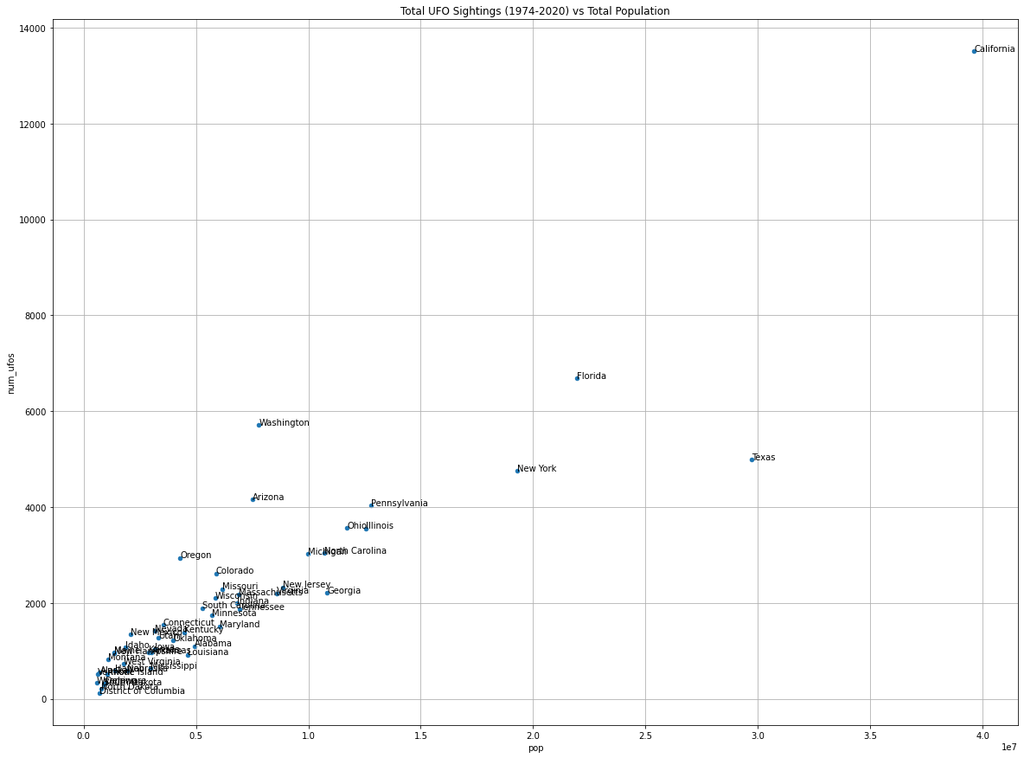

```python
fig,ax=plt.subplots()
merged.plot(kind='scatter', figsize=(20,15), ax=ax, grid=True, x='pop', y='num_ufos', title='Total UFO Sightings (1974-2020) vs Total Population', xlabel='state population', ylabel='total number of ufo reports from state')

for k,v in merged.iterrows(): # label each datapoint with state name
    ax.annotate(v['state_name'], (v['pop'], v['num_ufos']))
```

Based on this plot, we can see that high population does correlate with high numbers of ufo reports, and that this trend is fairly linear. To demonstrate this more clearly, lets add a regression line.

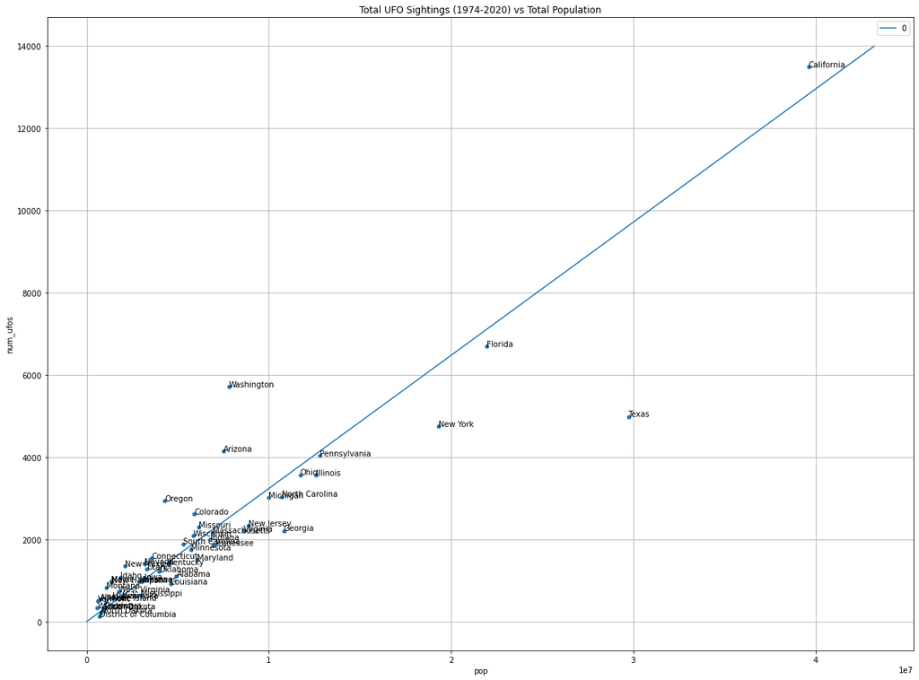

```python
line_func = np.poly1d(np.polyfit(merged['num_ufos'], merged['pop'], 1))
x = range(0,14001)
pd.DataFrame(x,line_func(x)).plot(figsize=(20,15), ax=ax, grid=True)
fig
```

As we noted previously, Texas appears to be a bit of an outlier in this case, as it has a comparatively low number of ufo reports for its high population. It's also worth noting that Washington also appears to stray from the trend somewhat, with a fairly high number of ufo reports despite its lower population. California, despite being an outlier in terms of both number of ufo reports and population size, still appears to follow the trend set by the rest of the data.

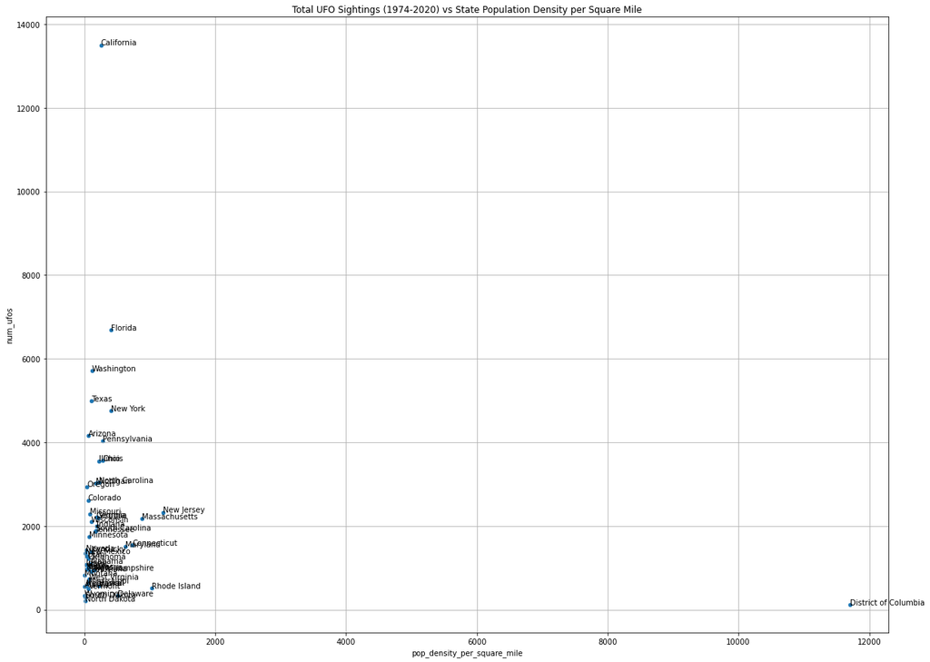

```python
fig,ax=plt.subplots()
merged.plot(kind='scatter', figsize=(20,15), ax=ax, grid=True, x='pop_density_per_square_mile', y='num_ufos', title='Total UFO Sightings (1974-2020) vs State Population Density per Square Mile', xlabel='state population density', ylabel='total number of ufo reports from state')

for k,v in merged.iterrows(): # label each datapoint with state name
    ax.annotate(v['state_name'], (v['pop_density_per_square_mile'], v['num_ufos']))
```

On this plot, there are two major outliers; California, which has an incredibly high number of ufo reports for its population density, and Washington DC, which simply has a much higher population density than any other state (given that it is technically not a state, and the area is mostly a city, which is high-density living by definition). Besides these outliers, we aren't getting a very good look at the data, so lets plot the data again without California or Washington DC.

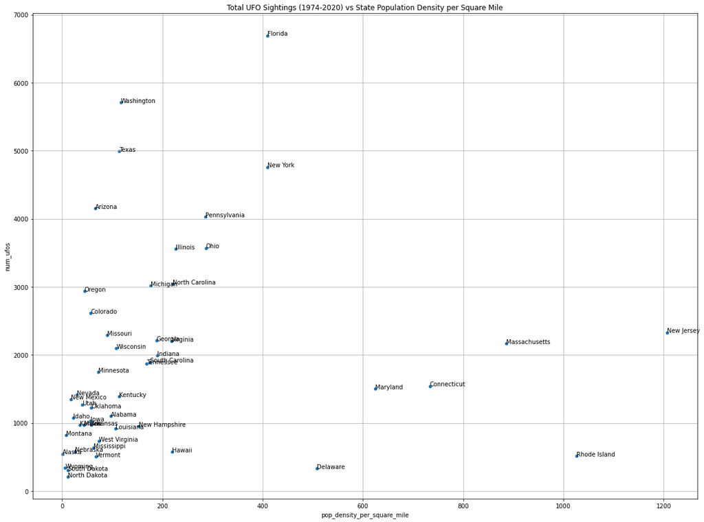

```python
fig,ax=plt.subplots()
merged_no_outliers = merged.drop([0]).drop([48]) # California, District of Columbia dropped
merged_no_outliers.plot(kind='scatter', figsize=(20,15), ax=ax, grid=True, x='pop_density_per_square_mile', y='num_ufos', title='Total UFO Sightings (1974-2020) vs State Population Density per Square Mile', xlabel='state population density', ylabel='total number of ufo reports from state')

for k,v in merged_no_outliers.iterrows(): # label each datapoint with state name
    ax.annotate(v['state_name'], (v['pop_density_per_square_mile'], v['num_ufos']))
```

There isn't as clear of a trend regarding number of ufo reports and population density as there was with number of ufo reports and total population. There seems to be a somewhat linear trend at lower densities, where a higher density correlates with a higher number of ufo reports. However, this trend begins to fall apart at higher population densities greater than 500. However, the outliers in this case--Delaware, Maryland, Connecticut, Massachusetts, Rhode Island, New Jersey, and Washington DC--appear to mostly be fairly small states, which is to be expected for states with a higher population density. Likely, this indicates there is little to no correlation regarding the number of ufo reports and population density, and any apparent trends are likely a consequence of the number of ufo reports' relationship with total population.

## Conclusion

While the exact reason is unclear, there appears to be a correlation between warmer weather and a higher number of reported ufo sightings. The average number of ufo sightings increases fairly dramatically from the spring months to the summer months. It's possible this correlation is due to people's habits in certain weather and during certain seasons; people are more likely to be outside, and therefore more likely to see any possible ufo sightings.

Of course, there are other factors that correlate with reported ufo sightings, such as population; California and Florida have the 1st highest and 3rd highest population out of all US states respectively. California in particular is also home to Hollywood, and in more populated areas (i.e. cities) that act as centers for tourism, fame and notoriety are more prominent cultural values. Whether that means people are more likely to lie for attention, or more likely to look for some way to share a ufo sighting if they think it may gain them notoriety is up for debate, and is largely speculative.

In terms of trends over the years 1974-2020, it appears that after 1996 is when the number of reported ufo sightings began to increase, after several years of staying fairly consistent. There are likely many factors, but an important one to note is the emergence of the internet as an increasingly important and widespread tool. Prior to the internet, it is likely that learning about any sort of organization dedicated to tracking ufo sightings would have to be done through word-of-mouth.

After 2014, there is a dramatic decrease in reported ufo sightings for all states, which reaches its lowest in 2018. The reason for this decrease is unclear, but one [possible contributing factor](https://www.businessinsider.com/head-of-ufo-report-centre-claims-reports-could-be-being-intercepted-2018-8) is that phenomena people would have attributed to ufos in the past are being attributed to drones as they become more common in commercial as well as personal use. Laws regarding the use of drones became less strict in 2015, as the Federal Aviation Administration (FAA) began allowing companies to use drones on a larger scale (i.e., Amazon using drones as a method of delivery), so long as they complied with guidelines. Prior to 2015, a special exemption was required to use drones in this manner.